# Objective

The objective of this application is to demonstrate the impact of a number of covariate effects on doxycycline pharmacokinetics.

# Doxycycline Population Pharmacokinetic Model

Doxycycline population pharmacokinetics (PK) in this application are described by a two-compartment model with oral absorption described by two transit compartments (Figure 1). The population PK model was developed using doxycycline plasma concentrations obtained from eight Phase I clinical trials comparing **single- and/or multiple doses** of Doryx Tablet, Doryx Capsule or Doryx MPC formulations in the fed or fasted status, in healthy individuals.

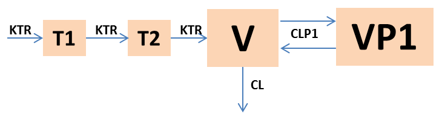

**Figure 1: Doxycycline Population Pharmacokinetic Model Schematic**

The final model includes these covariate effects:

- Formulation effects on relative bioavailability
- Absorption delay due to formulation and fed status effects
- Formulation effects on the transit absorption rate in the fed status
- Fed status effects on relative bioavaliability
- Gender effects on clearance

This application has been designed to allow the user to assess the influence of covariates on doxycyline concentrations, such as different formulations, fed/fasted status and gender. The final model is described as differential equations in the “Model” tab (written as mrgsolve code).

# Simulation Study Designs

The effect of these covariates can be evaluated in three different doxycycline dosing regimens:

1. Single dose: 120 mg Doryx MPC versus 100 mg Doryx Tablet over 96 hours
2. Clinical Regimen 1 (standard multiple dose regimen):
   - Doryx MPC - 120 mg every 12 hours on Day 1, then 120 mg every 24 hours on Days 2 to 7 *versus*
   - Doryx Tablet - 100 mg every 12 hours on Day 1, then 100 mg every 24 hours on Days 2 to 7
3. Clinical Regimen 2 (multiple dose regimen for severe infection):
   - Doryx MPC - 120 mg every 12 hours for 7 days
   - Doryx Tablet - 100 mg every 12 hours for 7 days

In all simulations:

- Each covariate subpopulation includes 500 individuals:
- Gender status is randomly assigned to each individual, 50:50
- Fat free mass (kg) is randomly drawn from a log-normal distribution with a mean of 55.49 kg and standard deviation of 0.09.

**Note:**

- Multiple-dose concentration data for Doryx MPC was not used in the development of this population PK model. Therefore, multiple-dose Doryx MPC simulations performed here are purely extrapolations from single-dose data.
- The total trial simulation duration presented here is 7 days (due to the apparent attainment of steady-state concentrations). Limited information can be acquired from performing longer simulations - although longer courses can be administered in the clinic.
- The population PK model was developed from doxycycline plasma concentrations following oral administration in healthy individuals. Therefore, the effect of disease status and/or sickness on doxycycline pharmacokinetics was not investigated here.